# Graph Exploration - Network Graph

Author

Phi Nguyen

Published

April 15, 2026

# 1 Loading Libraries

## 1.1 Network Graph

### 1.1.1 Also Known As:

Network Diagrams, Graphs

## 1.2 Example:

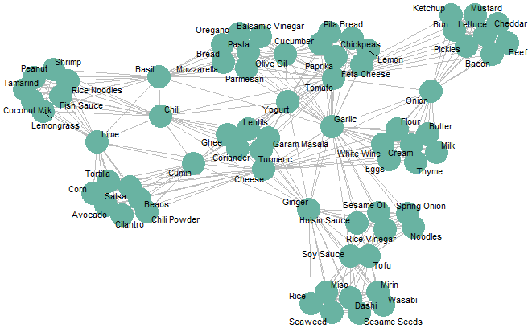

## 1.3 Data:

Data obtained from the Recipe Data set on Kaggle,this data set contains 500 recipes from various food blogs on the internet.

(Mujtaba Mateen. (2025). Recipe Dataset: Ingredients & Cooking Insights [Data set]. Kaggle. https://doi.org/10.34740/KAGGLE/DS/6625909)

Columns

- Recipe_ID: unique identifier for each recipe
- Cuisine: Categorical
- Ingredients: List of ingredients
- Category: Whether the food is for lunch, dinner or breakfast, dessert
- Cooking_Time: time to make in minutes
- Difficulty: How hard the dish is to make
- Cooking_Method: primary cooking method (Roasting, Baking, Grilling, ETC.)
- Serving Size: Number of people dish serves

## 1.4 Representation

Network diagrams show interconnections between different categorical entities. While there are many different variations of network diagrams, most have the following in common; Each entity is represented as a circle (node) and if there is a relationship between the two entities we draw a line between them (edge). Graph nodes that share lots of connections will be “pulled” towards each other, leading to the formation of distinct clusters. Network diagrams are used in many fields to plot out relationships

Some common uses for network diagrams

- Network diagrams can be used to plot relationships between different genes
- Can be used to map out computer networks and see which computers are communicating with each other
- View relationships between airports or visualize shipping routes

## 1.5 How to Read it & What to Look For

When reading a graph you should be looking for three main things; Clusters, Hubs, and Bridges. Clusters are sets of nodes that are highly related to each other, in network diagrams groups of nodes that are densely packed will indicate that those nodes are closely related. Hubs are nodes that have a lot of connections to other nodes, finally you’ll want to look for bridges, bridges are nodes that connect two separate clusters to each other.

With graphs they get more difficult to read as you add more nodes and edges in, this is why some graph add an interactive element that allows you to zoom in and out to make viewing easier.

## 1.6 Presentation Tips

**Annotation**: annotation is mainly used to label what each node in the graph represents

**Color:** Color can be used for two things primarily, if you have groups you can color graph nodes by group, there are also algorithms that will color nodes to identify where clusters are.

**Composition:** For graph’s the main compositional choice you will make is which layout to use; layouts are algorithms/procedures that determine how to position the graph nodes, there are many different types of layouts the most common are

- Random Layout: Nodes are placed randomly
- Circle layout: nodes are placed in a circle, this layout option ends up creating something similar to chord diagram
- Force Directed Layout: there are many different force directed layouts but they all have a similar goal; to position nodes so that all edges are similar length and to minimize the number of crossing edges. This works by having connected nodes “attract” each other and unconnected nodes “repel” each other

## 1.7 Variations and Alternatives

- Network diagrams, have a few variations a network diagram can be
- Directional or Non-Directional:
  - In Directional network diagrams edges go only one way, this means the relationship between nodes is one-sided. In an directional network diagram if A -> B this does not mean B -> A
  - Non-Directional Diagrams are the opposite, connections go both ways if A-> B then B -> A
- Weighted or Un-weighted:
  - Weighted graphs means that each connection has a weight attached to it; this weight indicates how strong the connection between two nodes are. A higher number indicates a stronger relationship whereas a smaller number is a weaker relationship (weights are usually indicated by thicker edge lines or a number on the edge)
  - Un-weighted graphs means we assume all edges between nodes are the same strength

## 1.8 How to Create

Network diagrams requires the data to be represented in one of three ways

1. Adjacency Matrix; An adjacency matrix is an N x N matrix where each row and column represents a node, if there is a value greater than one this means that those nodes share a connection
2. Edge List (also called Adjacency Lists): A dataframe where we list each node and it’s connections
3. Incidence Matrix (Less Common): M x N matrix where each row represents a node and each column represents an edge, each column will have two values in it that indicate which nodes it’s connecting

   ```r
   #reading in data
   recipe_data <- read_csv(here("Midterm","recipe_dataset.csv"))
   glimpse(recipe_data)
   ```

   ```
   Rows: 500
   Columns: 8
   $ Recipe_ID      <dbl> 1, 2, 3, 4, 5, 6, 7, 8, 9, 10, 11, 12, 13, 14, 15, 16, …
   $ Cuisine        <chr> "Mediterranean", "French", "Mexican", "Italian", "Japan…
   $ Ingredients    <chr> "Yogurt, Paprika, Tomato, Feta Cheese, Lemon, Chickpeas…
   $ Category       <chr> "Lunch", "Dinner", "Dinner", "Dinner", "Lunch", "Desser…
   $ Cooking_Time   <dbl> 76, 94, 57, 28, 62, 70, 109, 12, 36, 21, 78, 49, 56, 31…
   $ Difficulty     <chr> "Hard", "Easy", "Hard", "Hard", "Easy", "Hard", "Medium…
   $ Cooking_Method <chr> "Roasting", "Baking", "Grilling", "Grilling", "Sauteing…
   $ Serving_Size   <dbl> 5, 3, 5, 3, 6, 2, 3, 5, 4, 6, 3, 1, 1, 3, 6, 4, 6, 3, 2…
   ```

   ```r
   #data processing
   ingredients = c()
   unique_ingredients = c()

   #splitting up ingredients column into seperate table
   for (i in 1:nrow(recipe_data)) {

     ingredient = strsplit(recipe_data$Ingredients[i],", ")[[1]]
     ingredients = append(ingredients,list(ingredient))

     unique_ingredients = append(unique_ingredients,ingredient)
   }

   unique_ingredients <- unique_ingredients %>% unique()


   #creating adjacency matrix
   adjacency_matrix <- matrix(0,nrow=length(unique_ingredients),ncol = length(unique_ingredients),dimnames = list(unique_ingredients,unique_ingredients))

   #filling in adjacency matrix based on ingredients that share a row
   for (i in unique_ingredients) {
     for (j in unique_ingredients) {
       if(i != j) {
         count = 0
         for (x in 1:nrow(recipe_data)) {
           count = count + all(c(i,j) %in% ingredients[[x]])
         }
         adjacency_matrix[i,j] = count
       }
     }
   }

   #example of adjacency matrix representation
   pprint(adjacency_matrix)
   ```

   ```
   71 x 71 matrix of doubles:

               Yogurt    Paprika     Tomato ...    Pickles
   Yogurt   0.0000000 34.0000000 56.0000000 ...  0.0000000
   Paprika 34.0000000  0.0000000 29.0000000 ...  0.0000000
   Tomato  56.0000000 29.0000000  0.0000000 ... 26.0000000
   ...            ...        ...        ... ...        ...
   Pickles  0.0000000  0.0000000 26.0000000 ...  0.0000000
   ```

   ```r
   network = graph_from_adjacency_matrix(adjacency_matrix,mode="undirected")
   edge_list <- as_data_frame(network,what="edges")

   #edge list representation of data
   print(edge_list[] %>% slice_sample(n=15))
   ```

   ```
            from           to
   1      Tomato    Olive Oil
   2       Chili       Shrimp
   3       Onion          Bun
   4       Flour        Thyme
   5   Olive Oil        Bread
   6   Olive Oil   Mozzarella
   7      Ginger      Seaweed
   8    Tamarind       Peanut
   9      Tomato     Cucumber
   10      Basil Rice Noodles
   11       Miso Sesame Seeds
   12       Lime     Tortilla
   13     Yogurt        Chili
   14 Lemongrass     Tamarind
   15     Garlic         Eggs
   ```

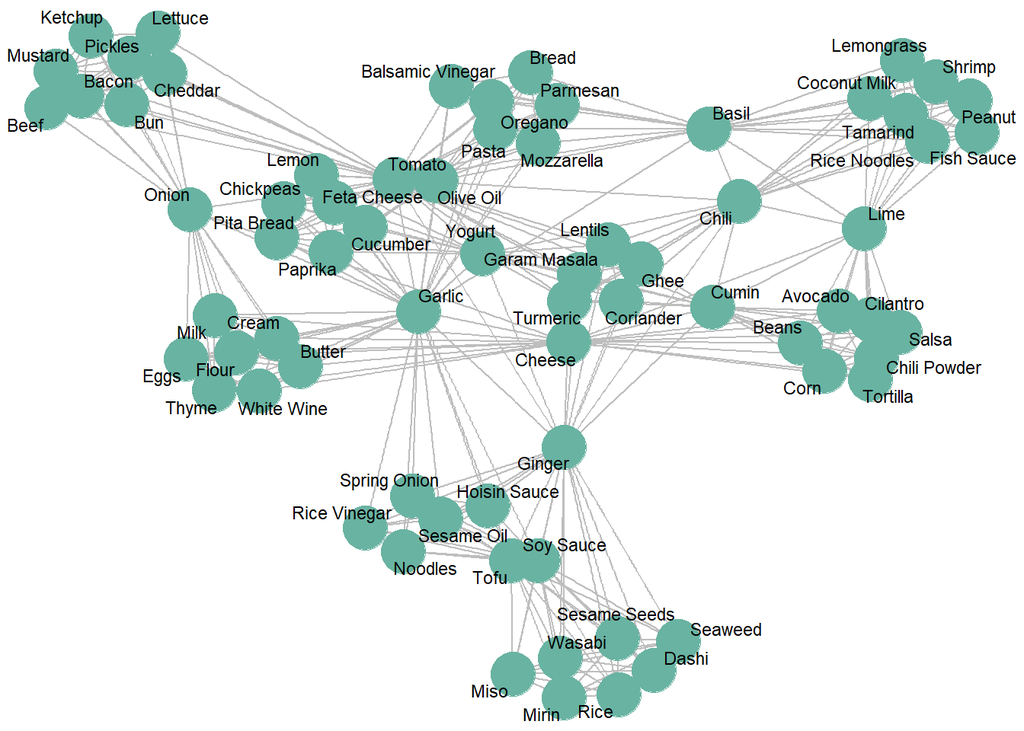

   ```r
   #creating graph
   ggraph(network,layout="igraph",algorithm="fr") +
     #draw edges
     geom_edge_link(color="gray") +
     #draw nodes
     geom_node_point(color="#69b3a2",size = 10,alpha = 1) +
     #draw node labels
     geom_node_text(aes(label=name), repel = TRUE, size=3, color="black") +
     theme_void()
   ```